# Divvy Cyclistic Analysis - 12 months

Peter A. Blackwell

2023-02-18

This analysis is based on the Divvy case study “Sophisticated, Clear, and Polished’: Divvy and Data Visualization”  
written by Kevin Hartman ( found here: https://artscience.blog/home/divvy-dataviz-case-study ).

The purpose of this script is to consolidate downloaded Divvy data into a single dataframe and then conduct simple analysis to help answer the key question of the case study:

#### “In what ways do members and casual riders use Divvy bikes differently?”

## SETUP STEPS

Install required packages:

- tidyverse for data import and wrangling
- lubridate for date functions
- ggplot for visualization
- dplyr for analysis

```r
library(tidyverse)
library(lubridate)
```

```r
library(ggplot2)
library(dplyr)
```

## STEP 1: COLLECT DATA

1. Upload Divvy datasets (csv files) here - using local directory ‘Cyclistic - data’

** NOTE - This uses data publicly available from the Divvy trip data site:  
https://divvy-tripdata.s3.amazonaws.com/index.html

License for the data usage is here:  
https://ride.divvybikes.com/data-license-agreement

```r
library(here)
month_1 <- read_csv(here("Cyclistic - data","202201-divvy-tripdata.csv"))
month_2 <- read_csv(here("Cyclistic - data","202202-divvy-tripdata.csv"))
month_3 <- read_csv(here("Cyclistic - data","202203-divvy-tripdata.csv"))
month_4 <- read_csv(here("Cyclistic - data","202204-divvy-tripdata.csv"))
month_5 <- read_csv(here("Cyclistic - data","202205-divvy-tripdata.csv"))
month_6 <- read_csv(here("Cyclistic - data","202206-divvy-tripdata.csv"))
month_7 <- read_csv(here("Cyclistic - data","202207-divvy-tripdata.csv"))
month_8 <- read_csv(here("Cyclistic - data","202208-divvy-tripdata.csv"))
month_9 <- read_csv(here("Cyclistic - data","202209-divvy-publictripdata.csv"))
month_10 <- read_csv(here("Cyclistic - data","202210-divvy-tripdata.csv"))
month_11 <- read_csv(here("Cyclistic - data","202211-divvy-tripdata.csv"))
month_12 <- read_csv(here("Cyclistic - data","202212-divvy-tripdata.csv"))
```

2. Stack individual months’ data frames into one big data frame

```r
all_trips <- bind_rows(month_1, month_2, month_3, month_4, month_5, month_6
                       ,month_7, month_8, month_9, month_10, month_11, month_12)
```

## STEP 2: CLEAN DATA (PART 1)

1. Remove columns not needed for analysis (station id columns, longitude/latitude columns)

```r
all_trips<- all_trips %>%
  select(-c(start_station_id,end_station_id:end_lng))
```

```r
all_trips_v2 <- na.omit(all_trips)
```

3. Run a count of ‘member_casual’ on the cleaned up data frame

```r
table(all_trips_v2$member_casual)
```

```
##
##  casual  member
## 1758189 2611171
```

4. Add custom columns to the all_trips_v2 dataset based off the ‘started_at’ column -

   extract the date without the timestamp, and month, day, year

```r
all_trips_v2$date <- as.Date(all_trips_v2$started_at) #The default format is yyyy-mm-dd
all_trips_v2$month <- format(as.Date(all_trips_v2$date), "%b")
all_trips_v2$day <- format(as.Date(all_trips_v2$date), "%d")
all_trips_v2$year <- format(as.Date(all_trips_v2$date), "%Y")
all_trips_v2$day_of_week <- format(as.Date(all_trips_v2$date), "%A")
```

5. Add a “ride_length” calculation to all_trips (in seconds)

   (reference - https://stat.ethz.ch/R-manual/R-devel/library/base/html/difftime.html)

```r
all_trips_v2$ride_length <- difftime(all_trips_v2$ended_at,all_trips_v2$started_at)
```

## STEP 3: INSPECT THE DATA

1. Inspect the structure of the columns

```r
str(all_trips_v2)
```

```
## tibble [4,369,360 × 13] (S3: tbl_df/tbl/data.frame)
##  $ ride_id           : chr [1:4369360] "C2F7DD78E82EC875" "A6CF8980A652D272" "BD0F91DFF741C66D" "CBB80ED419105406" ...
##  $ rideable_type     : chr [1:4369360] "electric_bike" "electric_bike" "classic_bike" "classic_bike" ...
##  $ started_at        : POSIXct[1:4369360], format: "2022-01-13 11:59:47" "2022-01-10 08:41:56" ...
##  $ ended_at          : POSIXct[1:4369360], format: "2022-01-13 12:02:44" "2022-01-10 08:46:17" ...
##  $ start_station_name: chr [1:4369360] "Glenwood Ave & Touhy Ave" "Glenwood Ave & Touhy Ave" "Sheffield Ave & Fullerton Ave" "Clark St & Bryn Mawr Ave" ...
##  $ end_station_name  : chr [1:4369360] "Clark St & Touhy Ave" "Clark St & Touhy Ave" "Greenview Ave & Fullerton Ave" "Paulina St & Montrose Ave" ...
##  $ member_casual     : chr [1:4369360] "casual" "casual" "member" "casual" ...
##  $ date              : Date[1:4369360], format: "2022-01-13" "2022-01-10" ...
##  $ month             : chr [1:4369360] "Jan" "Jan" "Jan" "Jan" ...
##  $ day               : chr [1:4369360] "13" "10" "25" "04" ...
##  $ year              : chr [1:4369360] "2022" "2022" "2022" "2022" ...
##  $ day_of_week       : chr [1:4369360] "Thursday" "Monday" "Tuesday" "Tuesday" ...
##  $ ride_length       : 'difftime' num [1:4369360] 177 261 261 896 ...
##   ..- attr(*, "units")= chr "secs"
##  - attr(*, "na.action")= 'omit' Named int [1:1298357] 257 511 513 980 981 1080 1081 1084 1143 1200 ...
##   ..- attr(*, "names")= chr [1:1298357] "257" "511" "513" "980" ...
```

```r
is.numeric(all_trips_v2$ride_length)
```

```
## [1] FALSE
```

```r
all_trips_v2$ride_length <- as.numeric(as.character(all_trips_v2$ride_length))
is.numeric(all_trips_v2$ride_length)
```

```
## [1] TRUE
```

## STEP 4: CLEAN DATA (PART 2)

1. Remove “bad” data

We will create a new version of the dataframe (_clean) since data is being removed

(reference - https://www.datasciencemadesimple.com/delete-or-drop-rows-in-r-with-conditions-2/ )

```r
   all_trips_clean <- all_trips_v2[!(all_trips_v2$start_station_name == "HQ QR" |          all_trips_v2$ride_length<0),]
summary(all_trips_clean)
```

```
##    ride_id          rideable_type        started_at
##  Length:4369291     Length:4369291     Min.   :2022-01-01 00:00:05.00
##  Class :character   Class :character   1st Qu.:2022-05-29 10:29:50.50
##  Mode  :character   Mode  :character   Median :2022-07-20 21:22:12.00
##                                        Mean   :2022-07-19 14:06:26.51
##                                        3rd Qu.:2022-09-14 18:22:14.00
##                                        Max.   :2022-12-31 23:59:26.00
##     ended_at                      start_station_name end_station_name
##  Min.   :2022-01-01 00:01:48.00   Length:4369291     Length:4369291
##  1st Qu.:2022-05-29 10:53:45.50   Class :character   Class :character
##  Median :2022-07-20 21:40:06.00   Mode  :character   Mode  :character
##  Mean   :2022-07-19 14:23:32.26
##  3rd Qu.:2022-09-14 18:38:30.00
##  Max.   :2023-01-01 18:09:37.00
##  member_casual           date               month               day
##  Length:4369291     Min.   :2022-01-01   Length:4369291     Length:4369291
##  Class :character   1st Qu.:2022-05-29   Class :character   Class :character
##  Mode  :character   Median :2022-07-20   Mode  :character   Mode  :character
##                     Mean   :2022-07-18
##                     3rd Qu.:2022-09-14
##                     Max.   :2022-12-31
##      year           day_of_week         ride_length
##  Length:4369291     Length:4369291     Min.   :      0
##  Class :character   Class :character   1st Qu.:    363
##  Mode  :character   Mode  :character   Median :    636
##                                        Mean   :   1026
##                                        3rd Qu.:   1141
##                                        Max.   :2061244
```

```r
summary(all_trips_v2$ride_length)
```

```
##    Min. 1st Qu.  Median    Mean 3rd Qu.    Max.
##  -10122     363     636    1026    1141 2061244
```

```r
# Run summary calculations on the ride length field for display
aggregate(all_trips_clean$ride_length ~ all_trips_clean$member_casual, FUN = mean)
```

```
##   all_trips_clean$member_casual all_trips_clean$ride_length
## 1                        casual                    1439.586
## 2                        member                     747.104
```

```r
aggregate(all_trips_clean$ride_length ~ all_trips_clean$member_casual, FUN = median)
```

```
##   all_trips_clean$member_casual all_trips_clean$ride_length
## 1                        casual                         831
## 2                        member                         539
```

```r
aggregate(all_trips_clean$ride_length ~ all_trips_clean$member_casual, FUN = max)
```

```
##   all_trips_clean$member_casual all_trips_clean$ride_length
## 1                        casual                     2061244
## 2                        member                       89594
```

```r
aggregate(all_trips_clean$ride_length ~ all_trips_clean$member_casual, FUN = min)
```

```
##   all_trips_clean$member_casual all_trips_clean$ride_length
## 1                        casual                           0
## 2                        member                           0
```

2. Re-order the day of the week so it is American Sunday->Saturday order

```r
all_trips_clean$day_of_week <- ordered(all_trips_clean$day_of_week, levels=c("Sunday", "Monday", "Tuesday", "Wednesday", "Thursday", "Friday", "Saturday"))
```

3. Make sure the months are in Jan - Dec. order

```r
all_trips_clean$month <- ordered(all_trips_clean$month, levels = c("Jan", "Feb", "Mar", "Apr", "May", "Jun", "Jul","Aug","Sep","Oct","Nov","Dec"))
```

## STEP 5: ANALYZE THE DATA

##### – Note: We will use median rather than average(mean) on analyses and plots to better flatten the extremes in values

1. Select number of rides, Median duration by customer type and day

```r
all_trips_clean %>%
  mutate(weekday = wday(started_at, label = TRUE)) %>%
  group_by(member_casual, weekday) %>%
  summarise(number_of_rides = n(),median_duration = median(ride_length))
```

```
## # A tibble: 14 × 4
## # Groups:   member_casual [2]
##    member_casual weekday number_of_rides median_duration
##    <chr>         <ord>             <int>           <dbl>
##  1 casual        Sun              301296             965
##  2 casual        Mon              210757             828
##  3 casual        Tue              196380             731
##  4 casual        Wed              203576             725
##  5 casual        Thu              230005             743
##  6 casual        Fri              248796             793
##  7 casual        Sat              367340             958
##  8 member        Sun              297722             588
##  9 member        Mon              375168             515
## 10 member        Tue              411244             516
## 11 member        Wed              412794             523
## 12 member        Thu              415887             527
## 13 member        Fri              360053             530
## 14 member        Sat              338273             602
```

2. Select number of rides, Median duration by customer type and month

```r
all_trips_clean %>%
  group_by(member_casual, month) %>%
  summarise(number_of_rides = n(),median_duration = median(ride_length)) %>%
  print(n=40)
```

```
## # A tibble: 24 × 4
## # Groups:   member_casual [2]
##    member_casual month number_of_rides median_duration
##    <chr>         <ord>           <int>           <dbl>
##  1 casual        Jan             12605             610
##  2 casual        Feb             15144             673
##  3 casual        Mar             67154             920
##  4 casual        Apr             91897             896
##  5 casual        May            220246             976
##  6 casual        Jun            292067             901
##  7 casual        Jul            311670             889
##  8 casual        Aug            270089             825
##  9 casual        Sep            220913             769
## 10 casual        Oct            151324             703
## 11 casual        Nov             73536             598
## 12 casual        Dec             31505             517
## 13 member        Jan             67523             448
## 14 member        Feb             74034             453
## 15 member        Mar            148827             494
## 16 member        Apr            180663             493
## 17 member        May            282299             579
## 18 member        Jun            328281             607
## 19 member        Jul            330996             600
## 20 member        Aug            335224             580
## 21 member        Sep            314227             551
## 22 member        Oct            262943             496
## 23 member        Nov            182226             464
## 24 member        Dec            103898             442
```

## STEP 6: CHARTS

1. Pie chart summary comparison of rider type for last 12 months

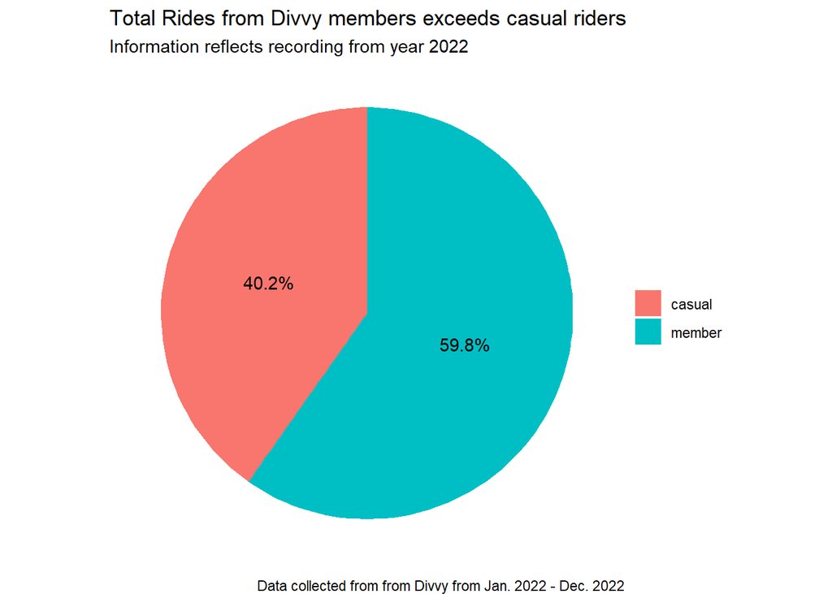

```r
all_trips_clean %>%
  group_by(member_casual) %>%
  summarise(number_of_rides = n()) %>%
  ggplot(aes(x = "", y = number_of_rides,fill=member_casual )) +
    geom_bar(stat="identity", width=1) +
    coord_polar("y", start=0) +
  geom_text(aes(label = paste0(round(number_of_rides / sum(number_of_rides) * 100, 1), "%")),
            position = position_stack(vjust=0.5)) +
  labs(x = NULL, y = NULL, fill = NULL) +
  labs(title = "Total Rides from Divvy members exceeds casual riders",
       subtitle = "Information reflects recording from year 2022",
       caption = "Data collected from from Divvy from Jan. 2022 - Dec. 2022") +
  theme_void()
```

2. Analyze ridership data by type -weekday, number of riders

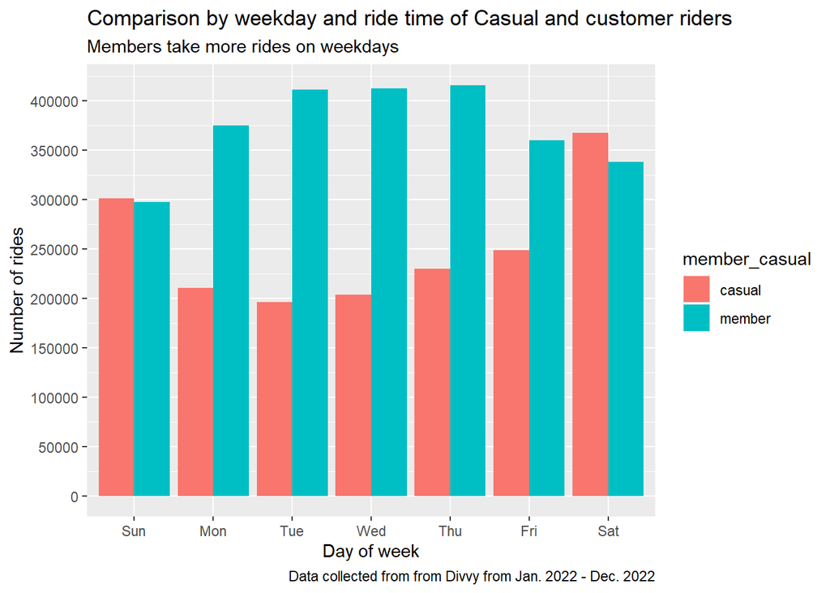

```r
all_trips_clean %>%
  mutate(weekday = wday(started_at, label = TRUE)) %>%
  group_by(member_casual, weekday) %>%
  summarise(number_of_rides = n()) %>%
  arrange(member_casual)  %>%
  ggplot(aes(x = weekday, y = number_of_rides, fill = member_casual)) +
  geom_col(position = "dodge") +
  ggtitle("Comparison by weekday and ride time of Casual and customer riders") +
  xlab("Day of week") +
  ylab("Number of rides") +
  labs(subtitle = "Members take more rides on weekdays",
    caption = "Data collected from from Divvy from Jan. 2022 - Dec. 2022") +
  scale_y_continuous(breaks=seq(00000,450000,by=50000))
```

3. Compare customer type over last 12 months by duration of ride

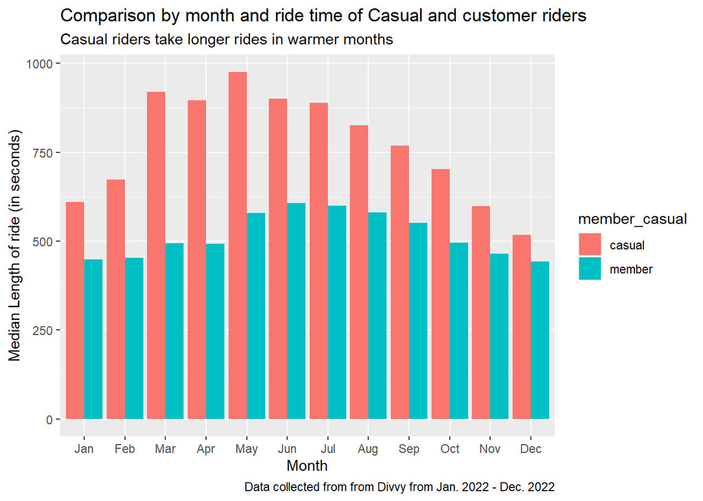

```r
all_trips_clean %>%
  mutate(weekday = wday(started_at, label = TRUE)) %>%
  group_by(member_casual, month) %>%
  summarise(number_of_rides = n()
            ,median_duration = median(ride_length)) %>%
  arrange(member_casual, month)  %>%
  ggplot(aes(x = month, y = median_duration, fill = member_casual)) +
  geom_col(position = "dodge") +
  ggtitle("Comparison by month and ride time of Casual and customer riders") +
  xlab("Month") +
  ylab("Median Length of ride (in seconds)") +
  labs(subtitle = "Casual riders take longer rides in warmer months",
    caption = "Data collected from from Divvy from Jan. 2022 - Dec. 2022")
```

4. Analyze ridership data by type and month - number of riders

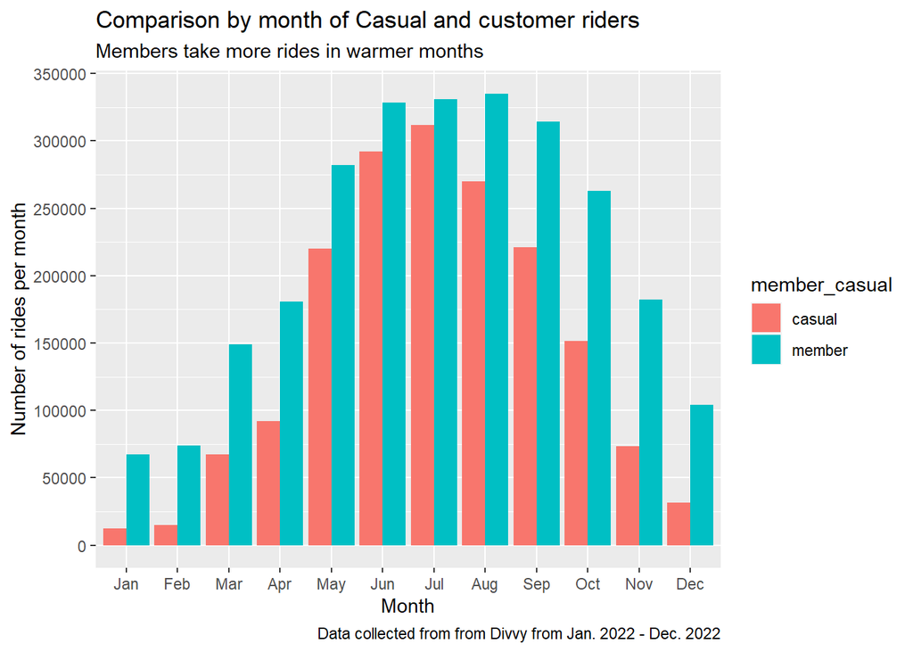

```r
all_trips_clean %>%
  mutate(weekday = wday(started_at, label = TRUE)) %>%
  group_by(member_casual, month) %>%
  summarise(number_of_rides = n()) %>%
  arrange(member_casual, month)  %>%
  ggplot(aes(x = month, y = number_of_rides, fill = member_casual)) +
  geom_col(position = "dodge") +
  ggtitle("Comparison by month of Casual and customer riders") +
  xlab("Month") +
  ylab("Number of rides per month") +
  labs(subtitle = "Members take more rides in warmer months",
    caption = "Data collected from from Divvy from Jan. 2022 - Dec. 2022") +
  scale_y_continuous(breaks=seq(0,350000,by=50000))
```

```r
library(ggrepel)
```

[figure not shown]

```r
# Another comparison of rider type
all_trips_clean %>%
  mutate(weekday = wday(started_at, label = TRUE)) %>%
  group_by(member_casual, weekday) %>%
  summarise(number_of_rides = n()
            ,median_duration = median(ride_length)) %>%
  mutate(Sat_value = if_else(weekday == 'Sat', member_casual,NULL)) %>%
  arrange(member_casual, weekday)  %>%
  ggplot( aes(x=weekday, y=median_duration, color=member_casual, group=member_casual)) +
  geom_line(size=1.25) +
  geom_text(aes(label = Sat_value),hjust="left") +
  ggtitle("Casual bike riders take longer rides than members") +
  theme(legend.position = "none") +
  xlab("Day of week") +
  ylab("Median length of ride in seconds") +
  labs(subtitle = "Difference is consistent on weekdays and weekends",
    caption = "Data collected from from Divvy from Jan. 2022 - Dec. 2022") +
  scale_y_continuous(expand = c(0, 0), limits = c(0, NA))
```

## STEP 7: OUTPUT FILES

##### Create a csv file that we will visualize in Excel, Tableau, or presentation software

```r
counts <- aggregate(all_trips_clean$ride_length ~ all_trips_clean$member_casual + all_trips_clean$day_of_week, FUN = median)
write.csv(counts, file = "C:/Users/peter/Documents/Google Data Analytics learning/Google Data Analysis docs - Part 8/Cyclistic - data/avg_ride_length.csv")
```